# Digital Contact Tracing Business Logic

## 7. Add transaction logic to support CRUD operations that span multiple tables

A transaction is a sequential group of database manipulation operations, which is performed as if it were one single work unit. In other words, a transaction will never be complete unless each individual operation within the group is successful. If any operation within the transaction fails, the entire transaction will fail.

Practically, we will club many SQL queries into a group and we will execute all of them together as a part of a transaction.

**Properties of Transactions**

Transactions have the following four standard properties, usually referred to by the acronym ACID −

Atomicity − This ensures that all operations within the work unit are completed successfully; otherwise, the transaction is aborted at the point of failure and previous operations are rolled back to their former state.

Consistency − This ensures that the database properly changes states upon a successfully committed transaction.

Isolation − This enables transactions to operate independently and transparently.

Durability − This ensures that the result or effect of a committed transaction persists in case of a system failure.

**COMMIT and ROLLBACK**

These two keywords Commit and Rollback are mainly used for MySQL Transactions.

When a successful transaction is completed, the COMMIT command should be issued so that the changes to all involved tables will be written to the disk.

If a failure occurs, a ROLLBACK command should be issued to return every table referenced in the transaction to its previous state.

Here, 4 functions have been created. Each function has a transaction logic for specific CRUD operation that spans multiple tables.For example, a particular function will only have 1 transaction logic for CREATE operation and another function will only have 1 transaction logic for UPDATE operation.

**NOTE** - For each CRUD operation, arguments are passed as attribute values to the functions. Arguments are passed as a list where the number of arguments are high.

CREATE operation on Person, AppUser and Patient tables. In the addNewTPatient function, we have to add a new patient. As Person is the super class whose sub class is AppUser, and AppUser’s subclass is Patient; we have to insert the entries in all the three tables serially as the super classes are not concrete meaning they can’t have a stanalone entry which is not present in one of their subclasses.In transition logic, if any 1 INSERT operation fails then the transaction doesn’t get committed. Here, trycatch is used to rollback the changes if error occurs while inserting the entries in any of the INSERT operations. The argument is passed as list as there are many attribute values that need to be inserted.

```r
# Transaction in addNewTPatient function

addNewTPatient <- function(w) {

tryCatch(
expr = {

dbBegin(practicum)

sqlt5 <- paste0(" INSERT INTO Person(pId,age,email,gender,pFirstName,pLastName,phoneNumber,addressId)
VALUES(",w[[1]],",", w[[2]],",","'",w[[3]],"'",",", "'", w[[4]], "'", ",", "'", w[[5]], "'",",", "'", w[[6]],"'", ",", w[[7]], ",", w[[8]],")")


dbGetQuery(practicum, sqlt5)

sqlt6 <- paste0(" INSERT INTO AppUser(pId,pLanguage, loggingDate, testResult)
                  VALUES(",w[[1]],",","'",w[[9]],"'",",","'",w[[10]],"'",",", "'", w[[11]],"'",")")

dbGetQuery(practicum, sqlt6)

sqlt7 <- paste0(" INSERT INTO Patient(pId, healthReportValidated,
                  typeOfTreatment, recovered)
                  VALUES(",w[[1]],",", "'", w[[12]],"'",",","'",w[[13]],"'",",","'", w[[14]],"'",")")

dbGetQuery(practicum, sqlt7)


dbCommit(practicum)

if(dbCommit(practicum) == TRUE)
print("CREATE transaction commited")

else{
  print("CREATE transaction rolled back")
  dbRollback(practicum)
}
 },
error = function(e){print(paste("INSERT statement error : Transaction Rolled Back :", e))
  dbRollback(practicum)
  }
)
}


# Creation of list which will be passed as an argument to addNewTPatient() function

w <- list(tpId = 231,tage =23, temail = 'mikkel.neil@gmail.com', tgender = 'M',tpFirstName = 'Mikkel', tpLastName = 'Neilson',
tphoneNumber = 9898899999,taddressId=20,tpLanguage= 'Hindi',tloggingDate = '2020-01-01 10:10:10 ',ttestResult = 'Positive', thealthReportValidated ='Yes',
ttypeOfTreatment = 'Coronil' , trecovered = 'No' )


# Function call to addNewTPatient() with argument as list w which contains the attribute values to be inserted in Person, AppUser and Patient tables.

addNewTPatient(w)
```

```
## [1] "CREATE transaction commited"
```

**Output to show that the values have been inserted in Person, AppUser and Patient tables by joining them and filtering the pId that was sent as the argument in the list**

```r
dbGetQuery(practicum,paste0(" SELECT * FROM Person p, AppUser a, Patient pt WHERE p.pId = a.pId AND a.pId = pt.pId AND p.pId=", w[[1]] ) )
```

| pId | pFirstName | pLastName | email | gender | age | phoneNumber | addressId | pId | pLanguage | loggingDate | testResult | pid | healthReportValidated | typeOfTreatment | recovered |
| --- | --- | --- | --- | --- | --- | --- | --- | --- | --- | --- | --- | --- | --- | --- | --- |
| 231 | Mikkel | Neilson | mikkel.neil@gmail.com | M | 23 | 9898899999 | 20 | 231 | Hindi | 2020-01-01 10:10:10 | Positive | 231 | Yes | Coronil | No |

READ operation on Location and Zip. Here, the SELECT statement will be executed for Location and Zip tables serially in a transaction for a particular zipCode which is being sent as an agument.

READ-ONLY transactions are important as In a highly concurrent application it could (theoretically) happen that data we have read in the first select is modified before the other selects are executed.

If that is a situation that could occur in our application then we should use a transaction to wrap our selects.

There is no possible way to show that the operations worked in a READ-ONLY transaction as we don’t have mult-iuser setup in our case to show the concurrency. So, in this case we have printed the message that the transaction commits if the dbCommit() value is TRUE.

```r
# Transaction in readTZip function

readTZip <- function(zid) {

tryCatch(

expr={ dbBegin(practicum)

sqlt3 <- paste0(" SELECT * FROM Location
                  WHERE zipCode =", zid)

dbGetQuery(practicum, sqlt3)

sqlt4 <- paste0(" SELECT * FROM Zip
                  WHERE zipCode =", zid)

dbGetQuery(practicum, sqlt4)

dbCommit(practicum)

if(dbCommit(practicum) == TRUE)
print("READ transaction commited")

else{
  print("READ transaction rolled back")
  dbRollback(practicum)
}

},
error=function(e){
  print(paste("SELECT statement error : Transaction Rolled Back :", e))
  dbRollback(practicum)
}
)
}

# Function Call to readTZip function with argument 66337 to view the particular record in both Location and Zip table serially

readTZip(66337)
```

```
## [1] "READ transaction commited"
```

**The database state to show the before image prior to the UPDATE operation for a particular zipCode from Location and Zip tables which will be passed as an argument in the next step as zidOld.Here, the old zipCode will be displayed by joining the Location and Zip tables and filtering the old zipCode that was sent as the argument in the function**

```r
dbGetQuery(practicum, paste0("SELECT * FROM Location l, Zip z
                       WHERE l.zipCode = z.zipCode AND l.zipCode =", 66337))
```

| addressId | blockNumber | street | zipCode | zipCode | city | state |
| --- | --- | --- | --- | --- | --- | --- |
| 20 | V3 | P.O. Box 949, 6858 Amet, Road | 66337 | 66337 | León | Gto |

UPDATE operation on Location and Zip. Here, the UPDATE operation will be performed on Location and Zip tables serially. If UPDATE operation is not implemented for one table then it will not be implemented for other table too. 2 arguments are being passed here, zidOld is the old value of zipCode which will be updated to the new value of zidNew. Normally, if we can’t implement this due to referntial integrity constraint between Location and Zip table, but we can do this by using transactions.

```r
# Transaction in updateTZip function


updateTZip <- function(zidOld, zidNew) {

tryCatch(
expr = {

dbBegin(practicum)

dbGetQuery(practicum,"SET @@FOREIGN_KEY_CHECKS=0")

sqlt1 <- paste0(" UPDATE Location SET zipCode =", zidNew,
                " WHERE zipCode =", zidOld)

dbGetQuery(practicum, sqlt1)

sqlt2 <- paste0(" UPDATE Zip SET zipCode =", zidNew,
                " WHERE zipCode =", zidOld  )

dbGetQuery(practicum, sqlt2)

dbGetQuery(practicum,"SET @@FOREIGN_KEY_CHECKS=1")

dbCommit(practicum)

if(dbCommit(practicum) == TRUE)
print("UPDATE transaction Commited")

else{
  print("UPDATE transaction rolled back")
  dbRollback(practicum)
}
},
error = function(e){print(paste("UPDATE statement error : Transaction Rolled Back :", e))
  dbRollback(practicum)
  }
)

}


# Function Call to updateTZip function with arguments 66337 and 10119 which are the old zipCode and new zipCode respectively.

updateTZip(66337,10119)
```

```
## [1] "UPDATE transaction Commited"
```

**Output to show that the values have been updated in Location and Zip tables by joining them and filtering the new zipCode that was sent as the argument in the function**

```r
dbGetQuery(practicum, paste("SELECT * FROM Location l, Zip z WHERE l.zipCode = z.zipCode AND (l.zipCode = 10119 OR l.zipCode =66337)"))
```

| addressId | blockNumber | street | zipCode | zipCode | city | state |
| --- | --- | --- | --- | --- | --- | --- |
| 20 | V3 | P.O. Box 949, 6858 Amet, Road | 10119 | 10119 | León | Gto |

**The database state to show the before image prior to the DELETE operation for a particular pId from Patient, AppUser and Person tables which will be passed as an argument in the next step by joining the tables and filtering the to be pId that is sent as the argument in the function in the next step.**

```r
dbGetQuery(practicum, paste0("SELECT * FROM Patient pt, AppUser a, Person p
                       WHERE pt.pId = a.pId AND a.pId = p.pId AND pt.pId =", 231))
```

| pid | healthReportValidated | typeOfTreatment | recovered | pId | pLanguage | loggingDate | testResult | pId | pFirstName | pLastName | email | gender | age | phoneNumber | addressId |
| --- | --- | --- | --- | --- | --- | --- | --- | --- | --- | --- | --- | --- | --- | --- | --- |
| 231 | Yes | Coronil | No | 231 | Hindi | 2020-01-01 10:10:10 | Positive | 231 | Mikkel | Neilson | mikkel.neil@gmail.com | M | 23 | 9898899999 | 20 |

DELETE operation on Patient, AppUser and Person tables. Here, a record will be deleted from Patient, AppUser and Person tables in order as Person is a super class that has a subclass AppUser having a subclass Patient. If a record is just deleted from Patient table then it will still have information in AppUser and Person tables. As both the super classes are not concrete, this will violate the generalization. Thus, the record should be deleted from all 3 tables.

```r
# pId of the tables is passed as an argument to the function for which the record needs to be deleted.


removeTPatient <- function(pId){

tryCatch(
expr = {

dbBegin(practicum)

sqlt8 <- paste0(" DELETE FROM Patient
                    WHERE pId =", pId)

dbGetQuery(practicum, sqlt8)


sqlt9 <- paste0(" DELETE FROM AppUser
                    WHERE pId =", pId)

dbGetQuery(practicum, sqlt9)

sqlt10 <- paste0(" DELETE FROM Person
                    WHERE pId =", pId)

dbGetQuery(practicum, sqlt10)


dbCommit(practicum)

if(dbCommit(practicum) == TRUE)
print("DELETE transaction Commited")

else{
  print("DELETE transaction rolled back")
  dbRollback(practicum)
}

  },
error = function(e){print(paste("DELETE statement error : Transaction Rolled Back :", e))
  dbRollback(practicum)}
)


}


# Function Call to removeTPatient function with argument 231 which is the pId for which the record will be deleted from all the 3 tables

removeTPatient(231)
```

```
## [1] "DELETE transaction Commited"
```

**Output to show that the record has been deleted in Patient, AppUser and Person tables by joining them and filtering the deleted pId that was sent as the argument in the function. Here, the output has no rows as the record has been deleted in all the 3 tables**

```r
dbGetQuery(practicum, paste0("SELECT * FROM Patient pt, AppUser a, Person p
                       WHERE pt.pId = a.pId AND a.pId = p.pId AND pt.pId =", 231))
```

| pid | healthReportValidated | typeOfTreatment | recovered | pId | pLanguage | loggingDate | testResult | pId | pFirstName | pLastName | email | gender | age | phoneNumber | addressId |
| --- | --- | --- | --- | --- | --- | --- | --- | --- | --- | --- | --- | --- | --- | --- | --- |

## 8. Query plan for two alternatives of the same query

The nested-loop join algorithm consists of a pair of nested FOR loops, one for each relation say, R and S. For each tuple r in R, every tuple s in S is retrieved and then checked whether the two tuples satisfy the join condition r[A]=s[B]. If the join condition is satisfied, then the values of these two tuples are concatenated, which is then added to the result.

**Nested Loop Join is only preferable when both or one of the relations fit entirely in the main memory, the cost of join operation will be bR +bS block transfers.**

In hash join algorithm, a hash function h is used to partition the tuples of each relation into sets of tuples with each set containing tuples that have the same hash value on the join attributes A of relation R and B of relation S. The algorithm is divided into two phases, namely, partitioning phase and probing phase. In partitioning (also called building ) phase, the tuples of relations R and S are partitioned into the hash file buckets using the same hash function h.

**The main property of hash join is that the tuples in the partition P1 or R need to be joined with tuples in the partition P1 of S. This is because of the fact that if tuples of relation R with some hash value hash to i, then the tuples of relation S with same hash value also hash to i.**

The hash join algorithm requires 3(bR +bS)+4n block transfers. **The first term 3(bR +bS ) represents that the block transfer occurs three times**—once when the relations are read into the main memory for partitioning, second when they are written back to the disk and third, when each partition is read again during the joining phase. **The second term 4n represents an extra overhead (2n for each relation) of reading and writing of each partition to and from the disk** —since the number of blocks occupied by each partition is slightly more than b R +b S because of partially filled blocks. The extra overhead of 4n is generally very small as compared to bR +bS and hence, can be ignored.

**Comparison between 2 joins** – The difference is subtle, but the “matching” means that the nested loop join can make use of an index. So, a nested loop join can have very poor performance (if the tables are relatively large and there are no indexes) or it can have really good performance (if it can make use of an index).

In a hash join, the database does a full-scan of the driving table, builds a RAM hash table, and then probes for matching rows in the other table. For certain types of SQL, the hash join will execute faster than a nested loop join, but the hash join uses more RAM resources. **Some queries will perform faster with NESTED LOOPS joins, some with HASH joins, while others favor sort-merge joins.**

So, here is an attempt to design a query which fetches the name and age of people who have severe symptoms represented using different query mechanisms. The query plan automatically chooses from Nested loop join and hash join based on the above explanation.

```r
## explain query1
explainquery1<-"EXPLAIN SELECT person.pFirstName, person.pLastName, person.age FROM person,symptom
 WHERE 'Severe' = (
 SELECT symptom.severity FROM appuser,has
 WHERE appuser.pId = has.pId AND has.sId = symptom.sId
 AND appuser.pId = person.pId)"

resQuery1<-dbGetQuery(practicum, explainquery1)
resQuery1
```

| id | select_type | table | partitions | type | possible_keys | key | key_len | ref | rows | filtered | Extra |
| --- | --- | --- | --- | --- | --- | --- | --- | --- | --- | --- | --- |
| 1 | PRIMARY | symptom | NA | ALL | NA | NA | NA | NA | 21 | 100 | NA |
| 1 | PRIMARY | person | NA | ALL | NA | NA | NA | NA | 100 | 100 | Using where; Using join buffer (hash join) |
| 2 | DEPENDENT SUBQUERY | appuser | NA | eq_ref | PRIMARY | PRIMARY | 4 | practicumv01.person.pId | 1 | 100 | Using index |
| 2 | DEPENDENT SUBQUERY | has | NA | eq_ref | PRIMARY,sId | PRIMARY | 8 | practicumv01.person.pId,practicumv01.symptom.sId | 1 | 100 | Using where; Using index |

Query 1 : Here the four tables person, appuser, has, symptom are first joined. Then ‘Severe’ symptoms are filtered from the list after the join operation takes place. The resultant list contains 28 rows.

After the analysis, illustrated below, we have observed that first the inner joins are applied which results into 2100 rows which further is filtered by “Severe” symptoms resulting into 28 rows. Also, the cost of all the operations/queries is 212.60 units while the time taken to execute the entire query lies between 3.386..14.072 units. Moreover, the execution is a little faster because of the already existing index on the primary key of appUser and Has each but it is delayed because ALL the rows are scanned by queries involving symptom and person tables.

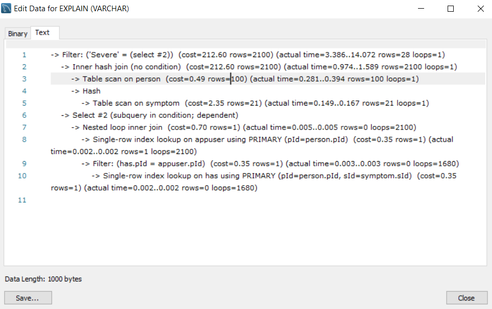

Fig 8.1 :Query 1 for Query plan Analysis

```r
## explain query2
explainquery2<-"EXPLAIN SELECT person.pFirstName, person.pLastName, person.age FROM person,appuser,has
 WHERE person.pId = appuser.pId AND appuser.pId = has.pId AND has.sId IN (
 SELECT symptom.sId FROM symptom
 WHERE symptom.severity = 'Severe');"

resQuery2<-dbGetQuery(practicum, explainquery2)

resQuery2
```

| id | select_type | table | partitions | type | possible_keys | key | key_len | ref | rows | filtered | Extra |
| --- | --- | --- | --- | --- | --- | --- | --- | --- | --- | --- | --- |
| 1 | SIMPLE | symptom | NA | ALL | PRIMARY | NA | NA | NA | 21 | 33.33 | Using where |
| 1 | SIMPLE | has | NA | ref | PRIMARY,sId | sId | 4 | practicumv01.symptom.sId | 4 | 100.00 | Using index |
| 1 | SIMPLE | appuser | NA | eq_ref | PRIMARY | PRIMARY | 4 | practicumv01.has.pId | 1 | 100.00 | Using index |
| 1 | SIMPLE | person | NA | eq_ref | PRIMARY | PRIMARY | 4 | practicumv01.has.pId | 1 | 100.00 | NA |

Query 2 : Here firstly, ‘Severe’ symptoms are filtered from the list which results into 7 rows and after that the join operation takes place resulting into 28 rows. Moreover, we have observed that the cost of all the operations/queries is 30.24 units while the time taken to execute the entire query lies between 17.086..18.222 units which is acceptable as the pages have to move in and out of main memory. However, when the pages are available in buffer space this time gets reduced by 1/100th.

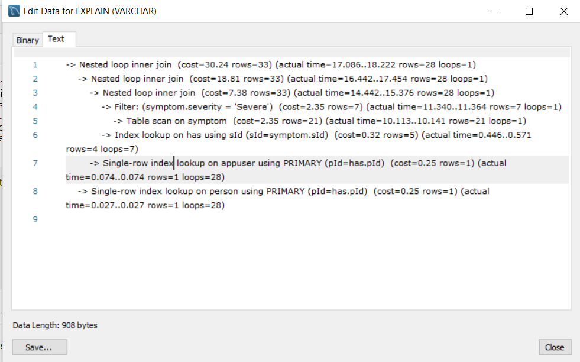

Fig 8.2 :Query 2 for Query plan Analysis

## 9. Query plan after adding Index for a non-key attribute

This query plan is an extension of Query 2 in Task 8. An index is added to the non-key attribute “severity” in table symptom.

When you have the index, the query planner can use the order that it reads data out of the indexes to do the nested loop without a sort, faster than a hash. Without the index it would do a sort, and the combination of sort + loop is slower than hash.

```r
##alter table to add index on attribute severity

alterTable1<- "ALTER TABLE symptom ADD INDEX symptomIndex (severity);"

tryCatch(
  expr={altQuery1<-dbSendQuery(practicum, alterTable1)
  print("Successfully added the column")
  },
  error=function(e){
    print(paste("Error occurred during column addition: ",e))
  }
)
```

```
## [1] "Successfully added the column"
```

Following is the performance analysis after adding the index.

```r
##explain query with index
explainquery1<-"EXPLAIN SELECT person.pFirstName, person.pLastName, person.age FROM person,appuser,has
 WHERE person.pId = appuser.pId AND appuser.pId = has.pId AND has.sId IN (
 SELECT symptom.sId FROM symptom
 WHERE symptom.severity = 'Severe')"

resQuery2<-dbGetQuery(practicum, explainquery1)

resQuery2
```

| id | select_type | table | partitions | type | possible_keys | key | key_len | ref | rows | filtered | Extra |
| --- | --- | --- | --- | --- | --- | --- | --- | --- | --- | --- | --- |
| 1 | SIMPLE | symptom | NA | ref | PRIMARY,symptomIndex | symptomIndex | 2 | const | 7 | 100 | Using where; Using index |
| 1 | SIMPLE | has | NA | ref | PRIMARY,sId | sId | 4 | practicumv01.symptom.sId | 4 | 100 | Using index |
| 1 | SIMPLE | appuser | NA | eq_ref | PRIMARY | PRIMARY | 4 | practicumv01.has.pId | 1 | 100 | Using index |
| 1 | SIMPLE | person | NA | eq_ref | PRIMARY | PRIMARY | 4 | practicumv01.has.pId | 1 | 100 | NA |

After creating the index, the cost has hiked because first the scanning of the index happens in the index directory and then the records are scanned in the original table pointed by the corresponding indexes. These records are usually scattered over several pages. Moreover, the index is of type Secondary Index as it has been added on an unordered and a non-key attribute- severity.

**The cost will further increase if the size of the database tends to grow which will lead to the creation of the multi-level indexes.**

But, the index has drastically improved the execution time from 17.086..18.222 units to 1.793..2.136 units. Also, the query is not accessing all the rows in any table. This increase in the accessing speed along with the reduction in the number of accessed rows to 7 are making this query plan a best fit.

[figure not shown]

Fig 9.1 :Query 2 after adding index